# Putting It All Together: Advanced Plotting

ASI: Introduction to R

Author

Affiliation

Dr Stevie Pederson

Black Ochre Data Labs  
The Kids Research Institute Australia

Published

September 3, 2025

# Customising Figures With `ggplot2`

## Recap

- Already learnt how to pipe data into `ggplot`
  - Can modify data ‘on the fly’
  - Don’t need multiple similar objects
- Explored `geom_point()`, `geom_col()`, `geom_boxplot()`
  - Used scales to modify colour, shape etc
- Tweaking plots for publication
  - Digging deeper with scales
  - Using `theme()` & `ggsave()`

## Setup

Some of those `NA` values will be a challenge from time to time

- Start a new script: `AdvancedPlotting.R`

```r
library(palmerpenguins)
library(tidyverse)
theme_set(theme_bw())
penguins
```

```
# A tibble: 344 × 8
   species island    bill_length_mm bill_depth_mm flipper_length_mm body_mass_g
   <fct>   <fct>              <dbl>         <dbl>             <int>       <int>
 1 Adelie  Torgersen           39.1          18.7               181        3750
 2 Adelie  Torgersen           39.5          17.4               186        3800
 3 Adelie  Torgersen           40.3          18                 195        3250
 4 Adelie  Torgersen           NA            NA                  NA          NA
 5 Adelie  Torgersen           36.7          19.3               193        3450
 6 Adelie  Torgersen           39.3          20.6               190        3650
 7 Adelie  Torgersen           38.9          17.8               181        3625
 8 Adelie  Torgersen           39.2          19.6               195        4675
 9 Adelie  Torgersen           34.1          18.1               193        3475
10 Adelie  Torgersen           42            20.2               190        4250
# ℹ 334 more rows
# ℹ 2 more variables: sex <fct>, year <int>
```

## Custom Scales

- Our previous plot (now with `NA` values)

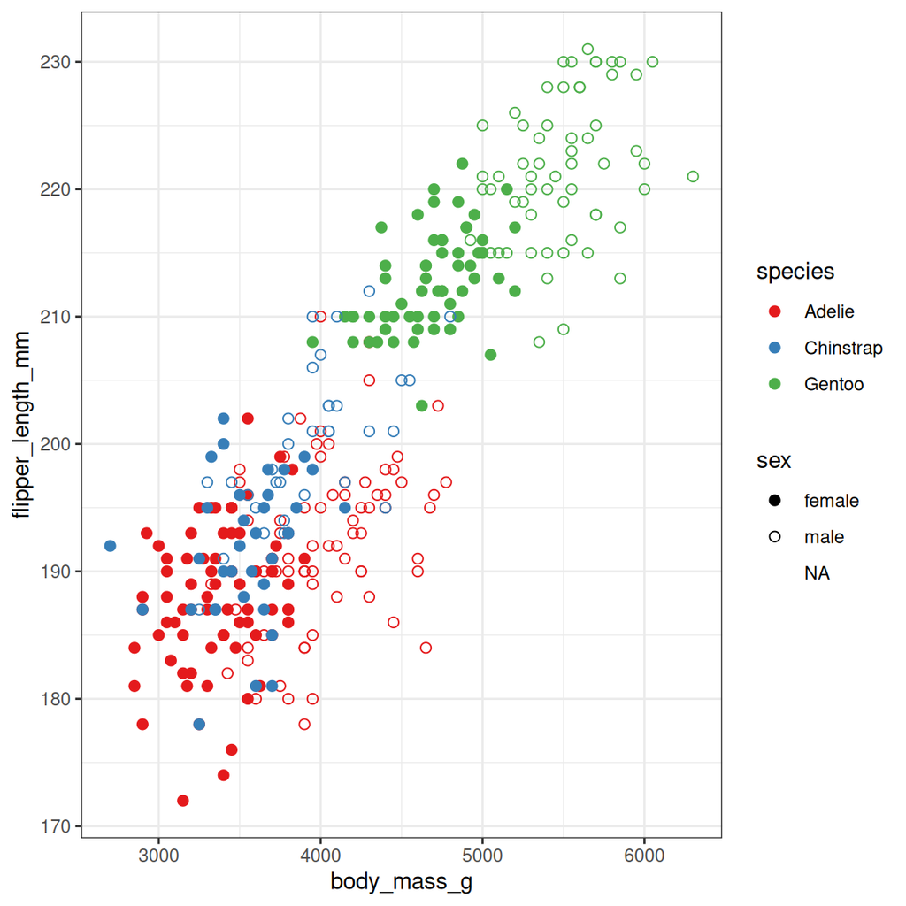

```r
penguins |>
  ggplot(
    aes(body_mass_g, flipper_length_mm)
  ) +
  geom_point(
    aes(colour = species, shape = sex),
    size = 2
  ) +
  scale_colour_brewer(palette = "Set1") +
  scale_shape_manual(values = c(19, 1))
```

## Custom Scales

- We’ve set `size` as a fixed value outside of `aes()`
  - Will override any values set inside `aes()`
- Notice that `NA` values are now in the legend but blank
  - We can set these by adding `na.value` inside `scale_shape_manual()`
  - Or apply `dplyr::filter(!is.na(sex))` before passing to `ggplot()`
- To ensure intended mappings we can *name values*

## Custom Scales

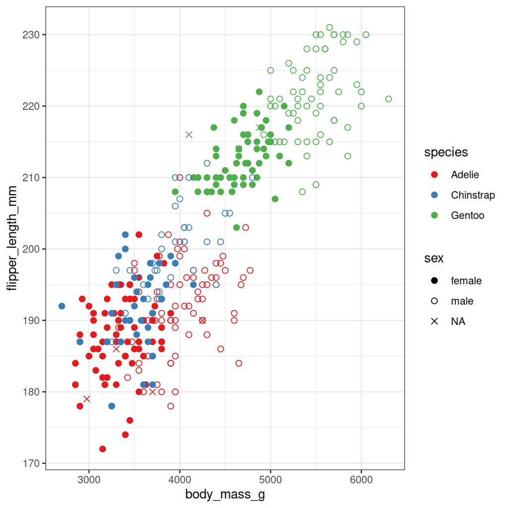

```r
penguins |>
  ggplot(
    aes(body_mass_g, flipper_length_mm)
  ) +
  geom_point(
    aes(colour = species, shape = sex),
    size = 2
  ) +
  scale_colour_brewer(palette = "Set1") +
  scale_shape_manual(
    values = c(female = 19, male = 1),
    na.value = 4
  )
```

## Choosing Colours

- Manual selection can also be applied to colours
- The complete set of 657 named colours is in the vector `colours()`

```r
colours() |> head(20)
```

```
 [1] "white"         "aliceblue"     "antiquewhite"  "antiquewhite1"
 [5] "antiquewhite2" "antiquewhite3" "antiquewhite4" "aquamarine"
 [9] "aquamarine1"   "aquamarine2"   "aquamarine3"   "aquamarine4"
[13] "azure"         "azure1"        "azure2"        "azure3"
[17] "azure4"        "beige"         "bisque"        "bisque1"
```

## Choosing Colours

- We can use `str_subset()` to find some options
  - Note the all named colours are previewed in the `RStudio` Script Window

```r
colours() |> str_subset("blue")
```

```
 [1] "aliceblue"       "blue"            "blue1"           "blue2"
 [5] "blue3"           "blue4"           "blueviolet"      "cadetblue"
 [9] "cadetblue1"      "cadetblue2"      "cadetblue3"      "cadetblue4"
[13] "cornflowerblue"  "darkblue"        "darkslateblue"   "deepskyblue"
[17] "deepskyblue1"    "deepskyblue2"    "deepskyblue3"    "deepskyblue4"
[21] "dodgerblue"      "dodgerblue1"     "dodgerblue2"     "dodgerblue3"
[25] "dodgerblue4"     "lightblue"       "lightblue1"      "lightblue2"
[29] "lightblue3"      "lightblue4"      "lightskyblue"    "lightskyblue1"
[33] "lightskyblue2"   "lightskyblue3"   "lightskyblue4"   "lightslateblue"
[37] "lightsteelblue"  "lightsteelblue1" "lightsteelblue2" "lightsteelblue3"
[41] "lightsteelblue4" "mediumblue"      "mediumslateblue" "midnightblue"
[45] "navyblue"        "powderblue"      "royalblue"       "royalblue1"
[49] "royalblue2"      "royalblue3"      "royalblue4"      "skyblue"
[53] "skyblue1"        "skyblue2"        "skyblue3"        "skyblue4"
[57] "slateblue"       "slateblue1"      "slateblue2"      "slateblue3"
[61] "slateblue4"      "steelblue"       "steelblue1"      "steelblue2"
[65] "steelblue3"      "steelblue4"
```

## Choosing Colours

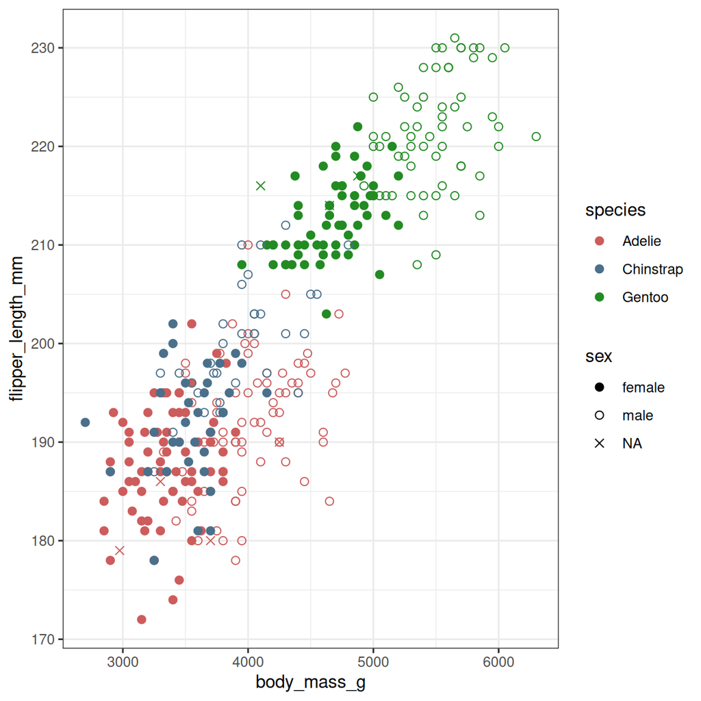

```r
penguins |>
  ggplot(
    aes(body_mass_g, flipper_length_mm)
  ) +
  geom_point(
    aes(colour = species, shape = sex),
    size = 2
  ) +
  scale_colour_manual(
    values = c(
      Adelie = "indianred",
      Chinstrap = "skyblue4",
      Gentoo = "forestgreen"
    )
  ) +
  scale_shape_manual(
    values = c(female = 19, male = 1),
    na.value = 4
  )
```

## Choosing Colours

- These can be defined as vectors and passed to every figure

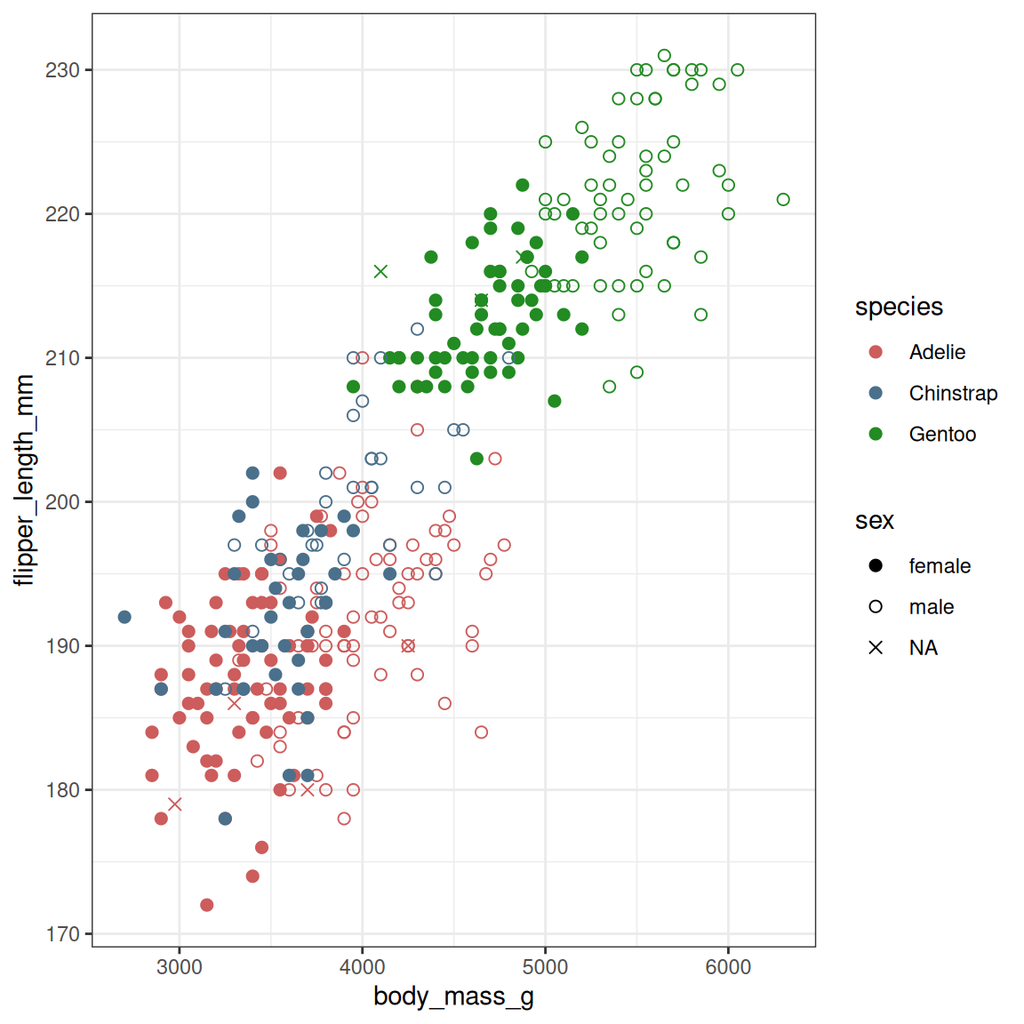

```r
my_colours <- c(
  Adelie = "indianred",
  Chinstrap = "skyblue4",
  Gentoo = "forestgreen"
)
penguins |>
  ggplot(
    aes(body_mass_g, flipper_length_mm)
  ) +
  geom_point(
    aes(colour = species, shape = sex),
    size = 2
  ) +
  scale_colour_manual(values = my_colours) +
  scale_shape_manual(
    values = c(female = 19, male = 1),
    na.value = 4
  )
```

## RGB Colours

- Colours can be defined using RGB format
- Start with a `#` then two values for red (R), green (G) and blue (B)
  - Values are hexadecimal: 0, 1, 2,…, 9, A, B, C, D, E, F
  - Gives 256 increments for each channel
  - `#000000` is all channels at zero $\implies$ *black*
- Also previewed in RStudio:

```r
## Full value in the Red & Green Channels without any blue: Yellow
"#FFFF00"
## Dim green a little & add some blue
"#FFAA70"
```

- Try changing a few values to get the hang of it

## Tweaking Labels

- `female` and `male` can be set to title-case using `labels = str_to_title`
  - `labels` takes a function and applies it to all labels

```r
penguins |>
  ggplot(
    aes(body_mass_g, flipper_length_mm)
  ) +
  geom_point(
    aes(colour = species, shape = sex), size = 2
  ) +
  scale_colour_manual(values = my_colours) +
  scale_shape_manual(
    values = c(female = 19, male = 1), na.value = 4,
    labels = str_to_title
  )
```

## Tweaking Labels

- `labels` can take functions using `\(x) some code modifying x`
  - Known as *inline functions*

```r
penguins |>
  ggplot(
    aes(body_mass_g, flipper_length_mm)
  ) +
  geom_point(
    aes(colour = species, shape = sex), size = 2
  ) +
  scale_colour_manual(values = my_colours) +
  scale_shape_manual(
    values = c(female = 19, male = 1), na.value = 4,
    labels = \(x) x |> str_to_title() |> str_extract("^[MF]")
  )
```

## Axis and Scale Titles

- Axis and Scale titles can be set using `labs()` or `scale_*(name = )`
- Both break the association between the source data and title

```r
penguins |>
  ggplot(
    aes(body_mass_g, flipper_length_mm)
  ) +
  geom_point(
    aes(colour = species, shape = sex), size = 2
  ) +
  scale_colour_manual(values = my_colours) +
  scale_shape_manual(
    values = c(female = 19, male = 1), na.value = 4,
    labels = \(x) x |> str_to_title() |> str_extract("^[MF]")
  ) +
  labs(
    x = "Body Mass (g)", y = "Flipper Length (mm)",
    colour = "Species", shape = "Sex"
  )
```

# Themes

## Themes

- The `theme()` layer provides control over general attributes
  - Font sizes, colours, types etc
  - Axis lines, tick marks, labels
  - Plot borders, fills, gridlines
  - Legend position & types
- Many attributes are set using elements:
  - `element_text()`, `element_line()`, `element_rect()`
  - `element_blank()`

## Themes

- Check the help page: `?theme` 😱
- Let’s save our plot as the object `p` $\implies$ then modify themes

```r
p <- penguins |>
  ggplot(aes(body_mass_g, flipper_length_mm)) +
  geom_point(
    aes(colour = species, shape = sex), size = 2
  ) +
  scale_colour_manual(values = my_colours) +
  scale_shape_manual(
    values = c(female = 19, male = 1), na.value = 4,
    labels = \(x) x |> str_to_title() |> str_extract("^[MF]")
  ) +
  labs(
    x = "Body Mass (g)", y = "Flipper Length (mm)",
    colour = "Species", shape = "Sex"
  ) +
  ggtitle("Palmer Penguins")
```

## Controlling Text Appearance

- Set font size using `element_text()` $\implies$ titles, legends and axis text

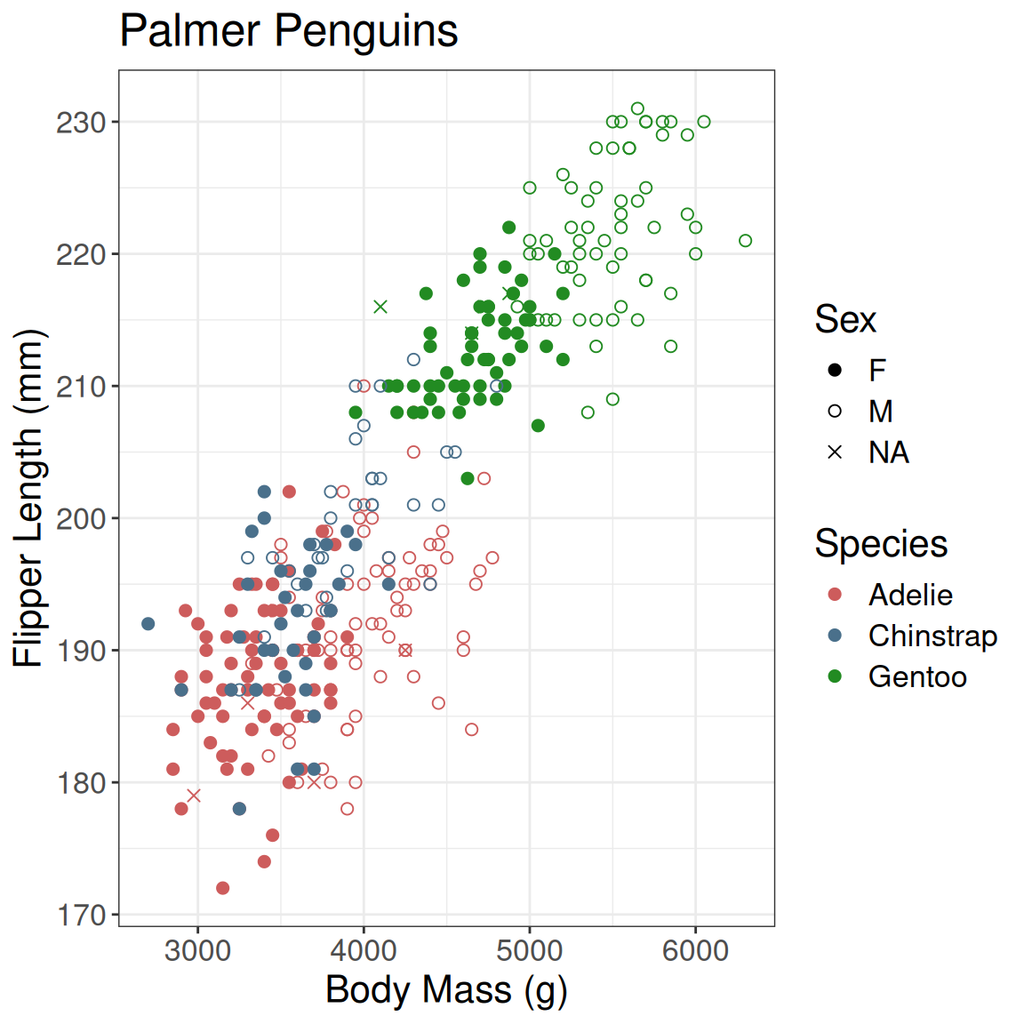

```r
## Set the global font size for better
## readability in presentations and
## publications. Also try the arguments
## family = "serif"
## face = "italic"
p +
  theme(text = element_text(size = 16))
```

## Controlling Text Appearance

- Plot titles are left-aligned by default $\implies$ use `hjust`

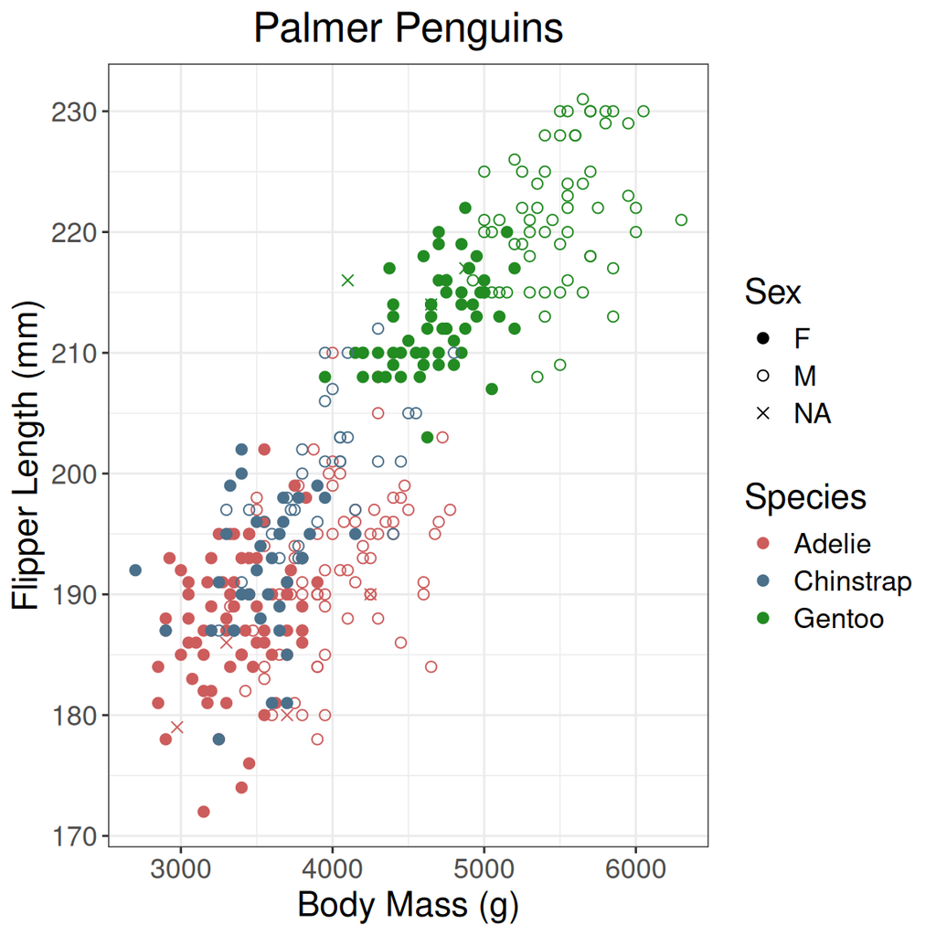

```r
## `element_text()` can also be applied to
## individual aspects, e.g. plot.title
## hjust controls horizontal adjustment
p +
  theme(
    text = element_text(size = 16),
    plot.title = element_text(hjust = 0.5)
  )
```

## Controlling Text Appearance

- Axis text can be rotated using `angle` (not great here)

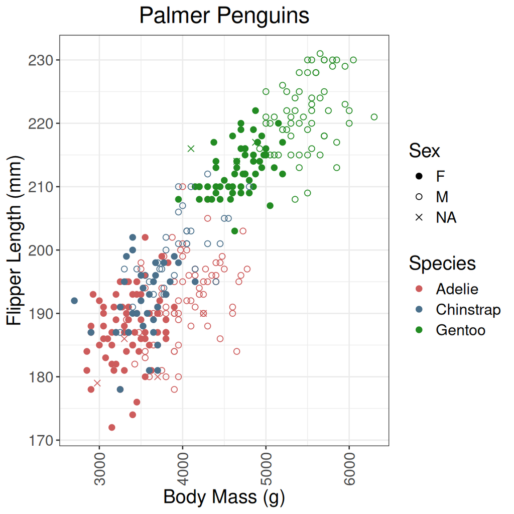

```r
## The defaults for text don't look great
## when rotating. Modifying placement using
## hjust = 1 (right-aligned) and
## vjust = 0.5 (centre aligned) helps.
## vjust/hjust are always with respect to
## text direction
p +
  theme(
    text = element_text(size = 16),
    plot.title = element_text(hjust = 0.5),
    axis.text.x = element_text(
      angle = 90, hjust = 1, vjust = 0.5
    )
  )
```

## Controlling Line Appearance

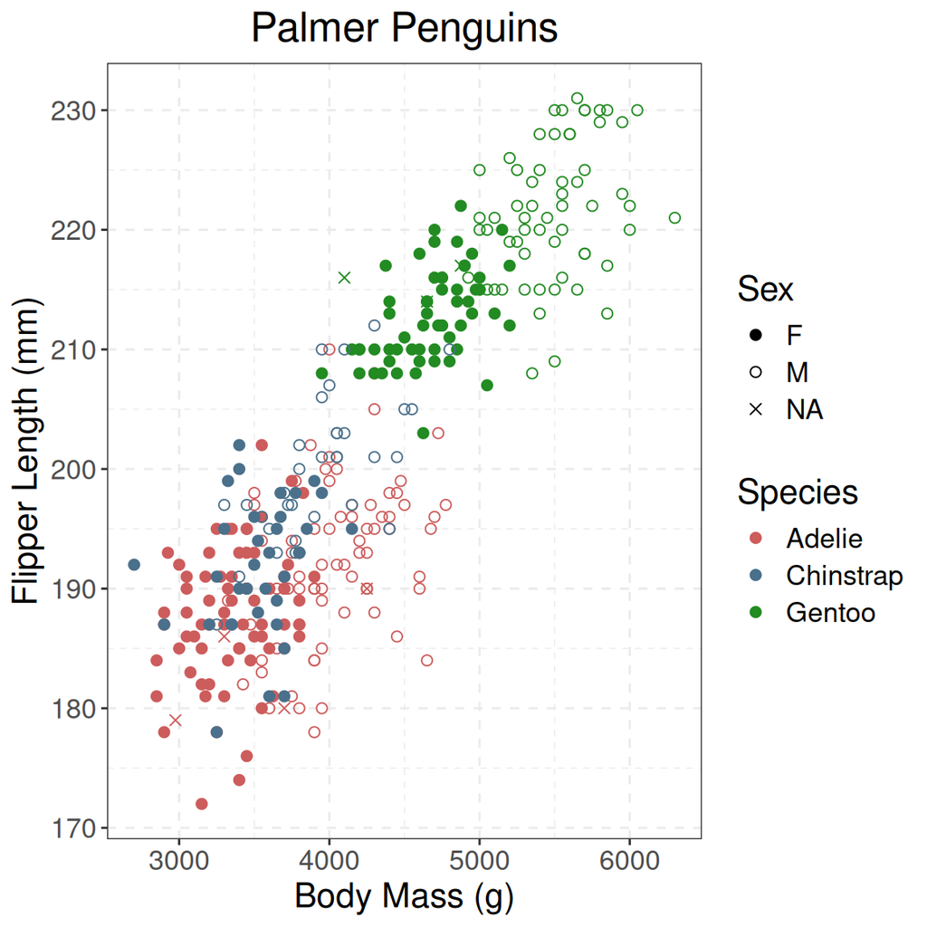

```r
## `element_line()` applies to grid-lines
## using panel.grid.
## Setting linetype = 2 will produce
## dashed lines.
## Also try experimenting with colour if
## you like
p +
  theme(
    text = element_text(size = 16),
    plot.title = element_text(hjust = 0.5),
    panel.grid = element_line(linetype = 2)
  )
```

## Removing Elements

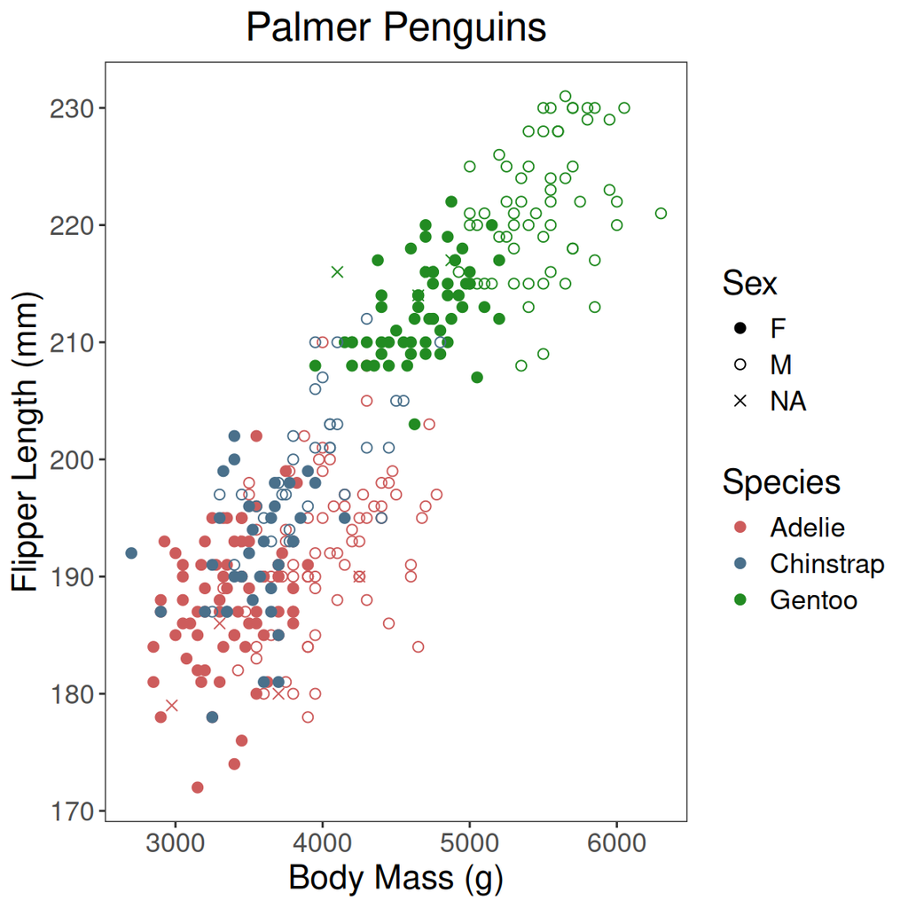

```r
## Grid lines can be removed using
## `element_blank()`
p +
  theme(
    text = element_text(size = 16),
    plot.title = element_text(hjust = 0.5),
    panel.grid = element_blank()
  )
```

## Using `element_rect()`

- The plotting region and overall panel use `element_rect()`

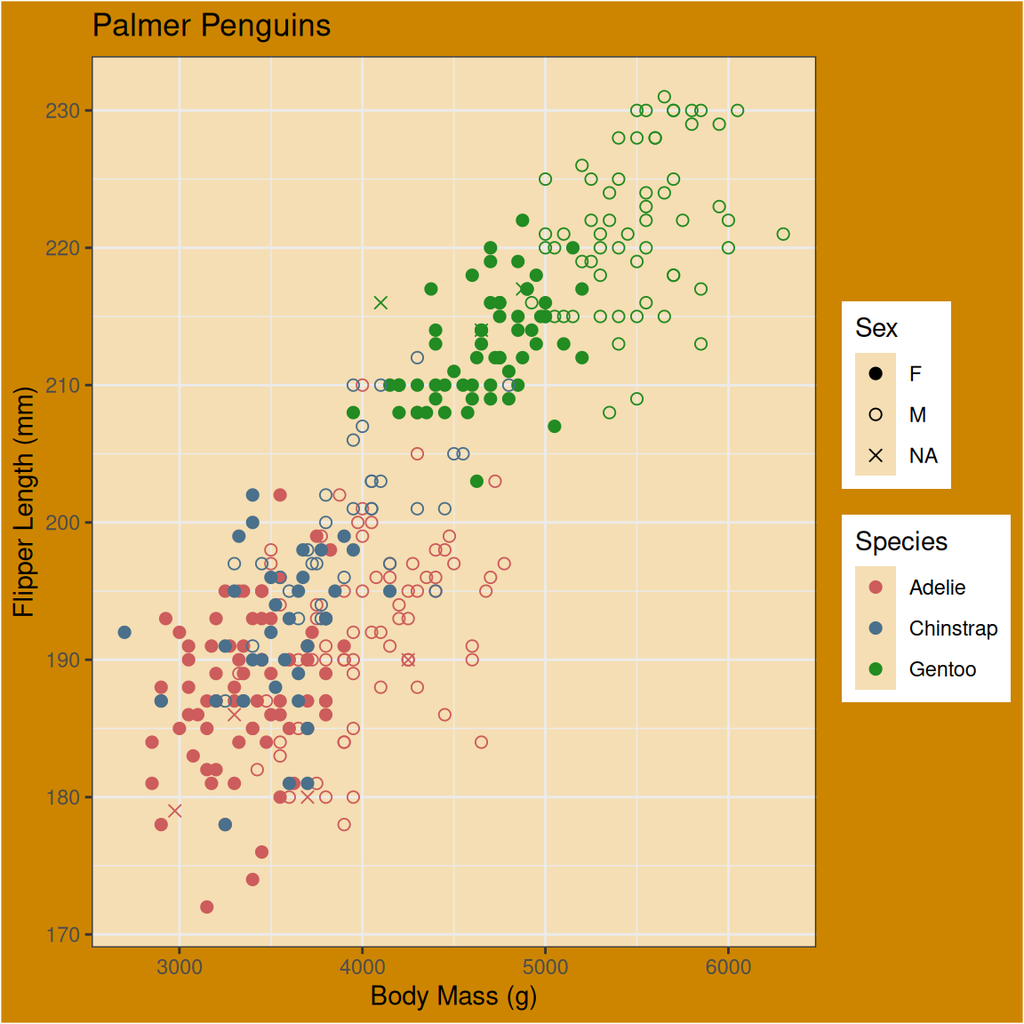

```r
## These are rarely required but if
## needed, the plotting region and
## panel with data are set separately
p +
  theme(
    plot.background = element_rect(
      fill = "orange3"
    ),
    panel.background = element_rect(
      fill = "wheat"
    )
  )
```

## Modifying Legends

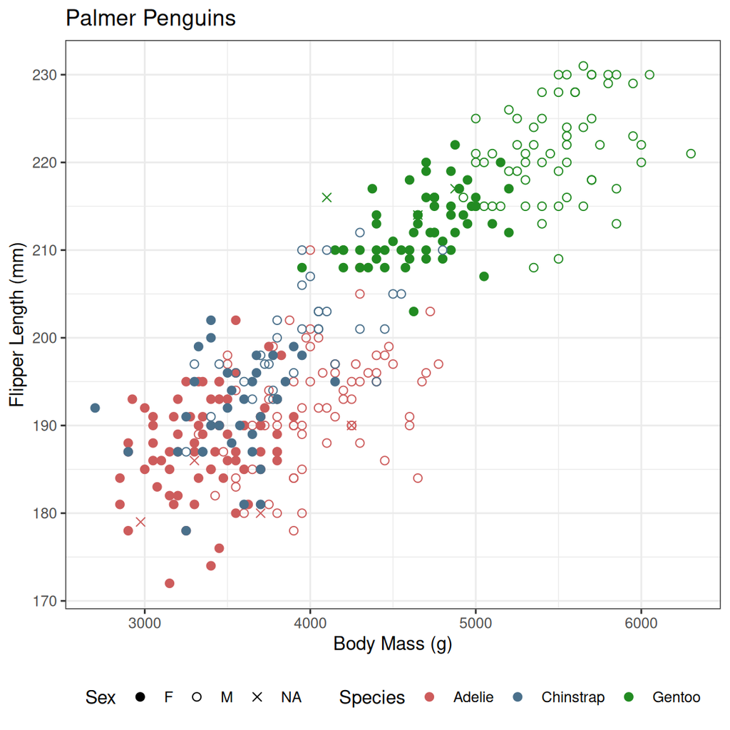

```r
## Legend position can be set as
## "top", "right", "bottom",
## "left", "none" or "inside"
p +
  theme(
    legend.position = "bottom"
  )
```

## Modifying Legends

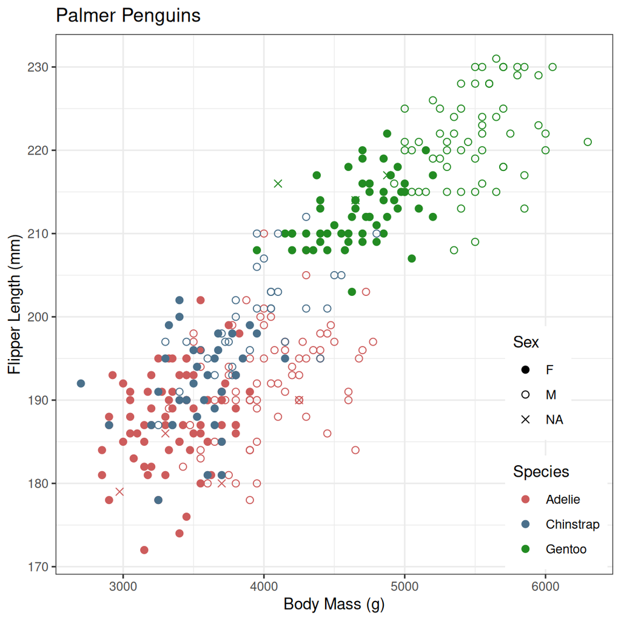

```r
## If placing the legend "inside", the
## position is set using a vector with
## values c(x, y)
## The default is to place the centre of
## the legend at that position.
## Changing the justification from
## c(0.5 ,0.5) to c(1, 0)
## (i.e. right, bottom) tells theme which
## part of the legend is placed at the
## co-ordinates
p +
  theme(
    legend.position = "inside",
    legend.position.inside = c(0.99, 0.01),
    legend.justification.inside = c(1, 0)
  )
```

## Saving To Disk

- The most common strategy is to call `ggsave()`
- Will automatically save the most recent plot

```r
?ggsave
```

- File types are auto-detected from the suffix, e.g. `"my_plot.png"`
  - Writes to PDF, PNG, JPEG, TIFF, SVG, EPS etc
- Width & Height are set using inches by default
  - Can be changed using `units = "cm"` or similar

## Saving To Disk

- May require multiple iterations getting font-sizes correct
- Try save near the size you expect:
  - Screen presentation and journals my be different
  - Err on the side of large font sizes

```r
## Save our last plot as a 7x7 inch PNG file
## Resolution can be set using dpi (default 300)
ggsave("my_plot.png", width = 7, height = 7)
```